# Short-term Rentals in Vancouver

Market Overview and Regulatory Impact Analysis

David Wachsmuth, Maxime Bélanger De Blois and Cloé St-Hilaire

15 November 2020

# 1 Short-term rentals in the City of Vancouver: Regulatory impacts

**Regulations in the City of Vancouver came to effect on April 18th of 2018, and started to get enforced at the beginning of September. For operators, the new short-term rental by-law implied the acquisition of a business licence as well as restrictions in location of operation and length of availability. The regulation caused a significant decline in active listings the months following, but rebounded the following summer of 2019. The number of commercial listings also reached pre-regulation levels in the summer season. Compared to other geographies, however, STR growth in the City of Vancouver has been of lesser proportions. While daily active listings declined by 2.4% in 2019 (compared to 2018), they increased by 21.9% in the rest of the CMA. While reservations and revenue increased by 5.2% and 2.6% respectively in the City of Vancouver in 2019, they increased by 35.9% and 35.0% in the rest of the CMA. Taking a closer look at properties on both sides of the Vancouver-Burnaby border, we can see that, although there has been a great increase in the number of active listings on the Burnaby side of the border, it has not come with a subsequent increase in revenue nor reservations. This oversupply of listings on the Burnaby side was not accompanied by a rise in demand.**

## 1.1 The City of Vancouver’s STR regulations

In April 2018, the City of Vancouver enacted regulations on the operations of short-term rentals in the City, definied as rentals offered for thirty or fewer consecutive days (City of Vancouver, 2020a). Under these regulations, each STR operator is required to obtain a license for their rental unit; these licenses are only issued for STRs operated out of a host’s principal residence, and are valid for a single calendar year. Licensed listings can either be the entire principal residence or individual rooms within the residence. Although the regulations apply to STRs listed on any platform, Airbnb is the only STR platform that agreed to require hosts in Vancouver to fill out a license field in their online listing, to engage in data sharing, and to undertake operator education (City of Vancouver, 2020b). In August 2018, shortly before the City’s announced start date for enforcement of the registration system, Airbnb removed approximately 2,400 listings which had not received licenses.

The regulations put in place by the City significantly constrain the type of STRs which are permitted to be operated in Vancouver. In particular, what we define as “multilistings” (listings operated by hosts who are simultaneously operating other listings) are by definition non-compliant, since multiple different listings cannot be simultaneously operated out of a principal residence. Moreover, frequently rented entire-home (FREH) listings are also highly likely to be non-compliant, since listings which are operated the majority of the year would be unlikely to also be a valid principal residence (excepting rare cases of very frequent travellers, for example).

In what follows we assemble evidence about the of the City’s regulations on the STR market. Given the significant restraints which the regulations impose on the market, their impacts should be highly visible if the regulations have been effective. If, by contrast, few impacts can be discerned, that implies that the regulations have not been effective. We carry out this task by analyzing the trajectory of STR activity in the City of Vancouver over time, and by comparing the City with a set of peer jurisdictions. This analysis collectively demonstrates that the City’s STR regulations have been effective at reducing STR activity and growth in Vancouver, and have accomplished that reduction in part by driving incoming visits to other municipalities within Metro Vancouver. However, the most significant impacts of the regulations were relatively short lived: both total active listings and commercial listings returned to pre-regulation levels within a year of the regulations being implemented.

## 1.2 The trajectory of post-regulation STR activity in Vancouver

The impact of the City’s regulations can be directly measured in two ways: changes in the total number of listings on STR platforms in Vancouver, and changes in commercial listings which are highly likely to be non-compliant. Because all Vancouver STR listings are required to be licensed whether or not they are active, in Figure 1.1 we show the total number of listings displayed each day alongside our standard metric of active daily listings. Displayed listings comprise active listings (i.e. listings which are either reserved or available for reservation) and inactive (blocked) listings which are visible on Airbnb or VRBO. Both indicators show a sharp drop following Airbnb’s mass removal of non-licensed listings in August 2018, but the decline is proportionally twice as large for displayed listings, which decreased 30.8% from August 20 to September 7, as it is for active listings, which decreased 17.8% over the same date range. Furthermore, displayed listings have never come close to regaining their pre-regulation numbers in Vancouver, while active listings had mostly recovered by the summer of 2019, a year after Airbnb’s mass removal. Put differently, a disproportionate share of the large decline in STRs which followed Airbnb’s mass removal was listings which were not actually in use on the platform anymore.

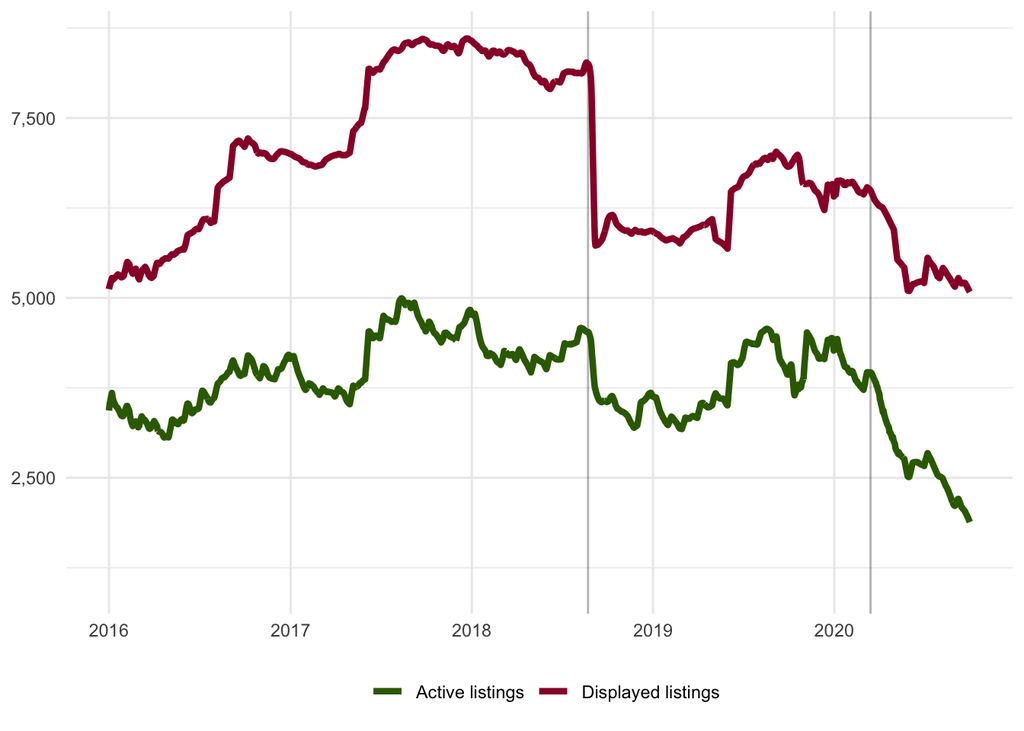

Figure 1.1: *Displayed and active listings in the City of Vancouver (7-day average)*

Trend analysis allows for a more precise estimate of the impact of regulation on active listings. Figure 1.2 compares the actual number of active listings with two scenarios for the listings which would have been expected based on pre-August-2018 trends. The higher, red line is a scenario where the growth rate of active listings from the previous two years continued into 2019. The lower, blue line is a scenario where aggregate growth in active listings stops, although seasonal variation continues. These two scenarios represent the plausible upper and lower bounds for what “natural” STR listing growth in Vancouver might have looked like in the absence of regulations. (As the subsequent section discusses, the continued-growth scenario is similar to Toronto’s actual STR market trajectory, while the no-growth scenario is similar to Montreal’s STR market trajectory.)

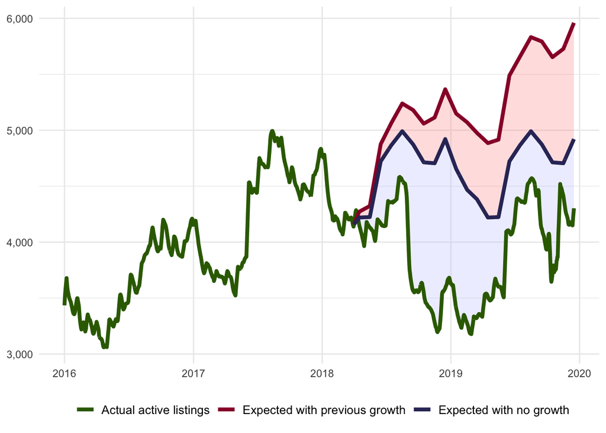

Figure 1.2: *Actual and expected active listings after implementation of regulations*

Since the 2018 regulations do not prohibit short-term rentals but merely limit them to hosts’ principal residences, the fact that active listings in Vancouver have been significantly reduced by the regulations is not on its own decisive evidence of the effectiveness of the regulations. A harder to measure—but arguably more important—metric is the number of commercial STRs operating in Vancouver, given that they are necessarily non-compliant with the City’s regulations. Figure 1.3 decomposes the trajectory of active listings shown above (in Figure 1.1) into commercial and non-commercial listings. The former are all listings which are either frequently rented entire-home (FREH) listings or multilistings. The graph shows that non-commercial listings experienced a noticable drop when Airbnb carried out its August 2018 mass listing removal, but that the number of these listings was already in decline. The quantity of commercial listings, meanwhile, experienced a much sharper drop in August 2018 (21.6% of all commercial listings were removed by Airbnb) and continued to decline for the rest of 2018. Commercial operations recovered throughout 2019, however, and reached a new all-time high (3,090) by the end of 2019.

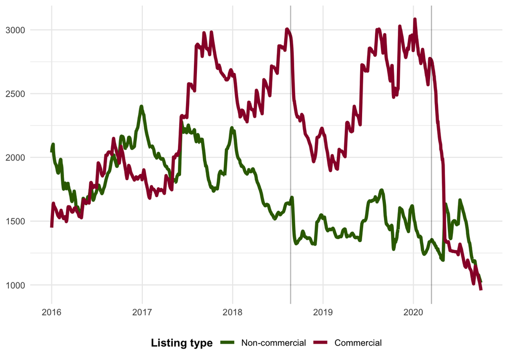

Figure 1.3: *Non-commercial and commercial active daily listings in Vancouver (7-day average)*

Figure 1.4 offers a closer look at how the actual number of commercial listings compares with two scenarios where the mid-2018 regulations are not enacted: a growth-as-usual scenario where the growth trend from the previous two years continues, and a no-growth scenario where commercial growth had stopped by the time that the City’s regulations were enacted. Unlike the trend analysis of all active listings, above, where under both scenarios the regulations are likely to have substantially reduced the number of daily active listings, the effect of the City’s regulations on commercial listings is highly sensitive to the scenario chosen. In the second half of 2019, the average difference between actual commercial listings and the two no-regulation counterfactuals was 980 under the continued-growth scenario, and 80 under the no-growth scenario. This is an enormous, twelve-fold difference. Under the assumption that commercial listing growth would have continued on its pre-regulation trend, we estimate that regulations have reduced the number of commercial operators by 35.0%. But under the assumption that commercial listing growth had leveled off when the regulations were introduced, we estimate that the City’s regulations have only reduced the number of commercial operators by 3.0%.

To be clear, however, the correct value for the “actual commercial listings” line in Figure 1.4 should be zero, given that all non-principal-residence STRs are forbidden under Vancouver’s regulations. Even allowing for some error in the measurement of commercial operators, at the end of 2019 there were almost certainly 2,500 or more listings operating in violation of the City’s principal residence rules.

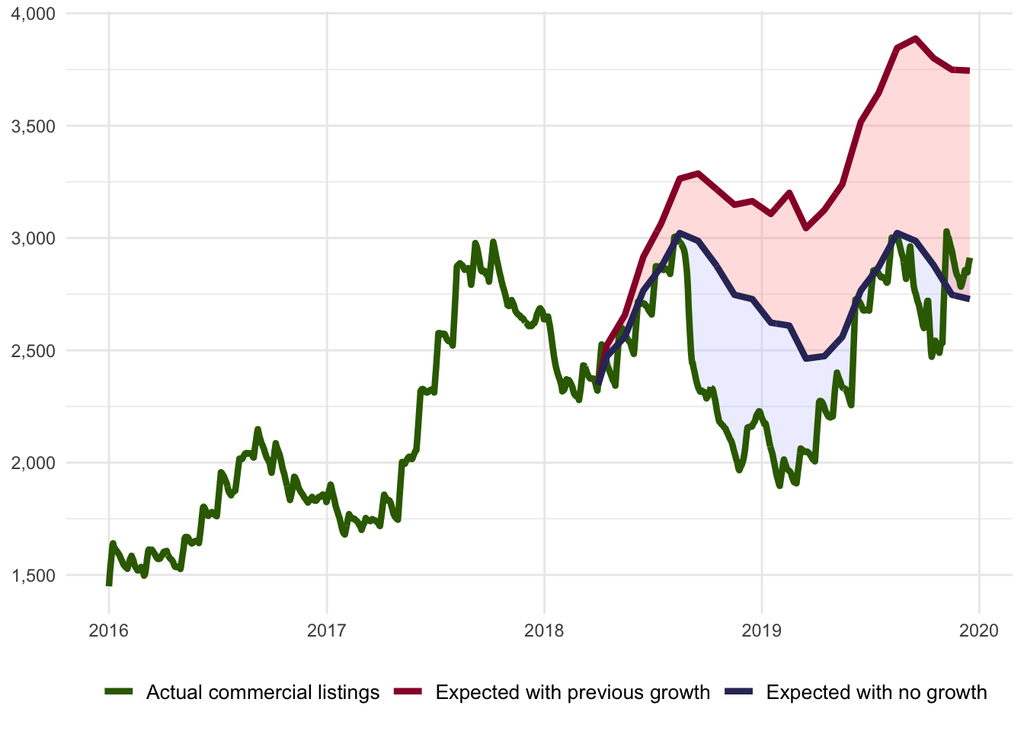

Figure 1.4: *Actual and expected commercial listings after implementation of regulations*

## 1.3 The City of Vancouver in comparison with Montreal and Toronto

The preceding analysis varies significantly with the underlying assumptions being made about the growth of Vancouver’s STR market prior to the introduction of the City’s regulations. If we assume that growth would have continued along its previous trajectory, then the regulations have had a major impact on the number of active listings, and in particular on the number of commercial operations. If growth were already leveling off prior to the introduction of the regulations, by contrast, then it is likely that the regulations have somewhat reduced the number of active listings, but have been ineffective at targeting the commercial operations which are not permitted under the rules.

There is no way to determine with certainty which of these scenarios would have occurred, but a promising strategy is to compare Vancouver with a set of similar jurisdictions which did not regulate their STR markets in mid-2018. In what follows we do this at multiple spatial scales, beginning with the other two largest STR markets in the country: Toronto and Montreal. The City of Toronto has recently implemented mandatory host registration and a principal-residence requirement which are very similar to Vancouver’s rules, but these were not active during the study period. The City of Montreal has rules which vary across the city, but in the key central-city boroughs commercial short-term rentals are largely forbidden. However, with no registration system in place during the study period, it has been widely understood that Montreal’s enforcement mechanisms have not been sufficiently strong to significantly affect the operation of commercial STRs. Toronto and Montreal thus represent zero- or low-regulation cases with which to compare Vancouver.

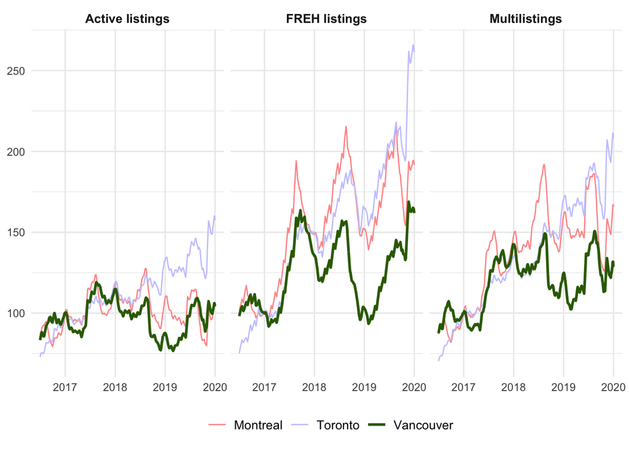

Figure 1.5: *Active listings (L), FREH listings (C), and multilistings (R) in Montreal, Toronto and Vancouver (2017-01-01 = 100)*

The divergence between Vancouver and Montreal and Toronto is even more significant with respect to commercial listings, which were prohibited by Vancouver’s regulations but were either de jure (Toronto) or de facto (Montreal) permitted in the other cases. The center and right panels of Figure 1.5 show, respectively, the trajectory of FREH listings and multilistings in the three cities. In both cases the three cities were on highly similar growth trajectories through 2017. Montreal’s FREH listings were growing at a 11.9% higher rate than Vancouver, while Toronto’s FREH growth rate was identical to Vancouver’s. Montreal’s multilistings were growing at a 6.9% higher rate than Vancouver, while Toronto’s were growing 1.6% faster. In the second half of 2019, by which point the temporary impacts of Airbnb’s mass listing removal in Vancouver would have subsided, the commercial side of Vancouver’s market looked dramatically different from either Montreal or Toronto. Montreal’s FREH listings had grown 29.5% faster than Vancouver’s, while Toronto’s had grown an incredible 51.4% faster. The numbers are similar for multilistings: Montreal outpaced Vancouver by 18.4%, and Toronto outpaced Vancouver by 40.9%.

These differences are summarized in Table 1.1. They strongly support the conclusion that the City of Vancouver’s regulations have durably reduced the commercial part of Vancouver’s STR market. Our “growth-as-usual” counterfactual had suggested that the regulations might have reduced commercial operators by 35.0%. Comparison with Montreal and Toronto adds additional evidence suggesting that this estimate is plausible.

Table 1.1: Montreal and Toronto listing trajectories in comparison with Vancouver (values are the growth rates from 1 January 2017 relative to Vancouver’s growth rates in the same time period)

| City | Year | Active listings | FREH listings | Multilistings |
| --- | --- | --- | --- | --- |
| Montreal | 2017 | 2.3% | 11.9% | 6.9% |
|  | 2019 (2H) | -3.0% | 29.5% | 18.4% |
| Toronto | 2017 | 1.0% | 0.0% | 1.6% |
|  | 2019 (2H) | 38.9% | 51.4% | 40.9% |

## 1.4 The City of Vancouver in comparison with the rest of the Vancouver region

STR activity in the CMA of Vancouver is mostly concentrated in the census subdivisions (CSD) of Richmond, Burnaby and Surrey. Richmond and Burnaby both represent around 20% of all daily active listings in the CMA, with similar shares of revenues. The growth rate of these two census subdivisions is 29.0% and 22.9%, respectively. While Surrey has less daily active listings than the first two CSDs, its active listings growth is 26.9%, and its revenue growth, 45.0%. This above-average growth in neighbouring regions might be a migration of the growth of STR activity in CSDs that are not subject to regulations.

## 1.5 The eastern edge of the City of Vancouver in comparison with the western edge of the City of Burnaby

We also conducted a comparative analysis between two sets of homogeneous listings: the first is a 1-kilometer buffer on the eastern side of the City of Vancouver, and the second is a 1-kilometer buffer on the western side of Burnaby. The following section will summarize the conclusions of this analysis in order to inform on the impact of STR regulations for STR listings.

Number of available daily listings grew substantially stronger in Burnaby’s than in the City’s buffer, but reservations numbers are very similar. Most likely to avoid regulations, new STR operations have moved to the outskirts of the city, while the demand has not changed in any way on both sides of the border. This has led to an increase in the supply of listings outside the City of Vancouver, without a subsequent increase in demand (illustrated by the similar levels of daily revenues and reserved listings).

The restrictions in Vancouver might have motivated STR hosts outside the city borders to start operating STRs commercially. When comparing properties on both sides of the border, we can see that there has been more growth in commercial listings in Burnaby (with unprecedented peaks in the summer and winter of 2019), but that commercial properties on the Vancouver side have also increased.